# 3 Python Libraries for Telecom Engineers

Python is a versatile programing language. What that means is it has little bit to offer- things it can do- for almost anyone even a little technically inclined.

It is a common misconception that only professional devolopers use these programming tools. To the contrary, a large selection of well-documented python libraries are being written by people who are not computer engineers. Case in point: The sci-kit learn library was started by doctors to help them classify cancerous and non-cancerous cells.

So join me in exploring those libraries which maybe of interest to telecommunication engineers.

## 3. Scikit Radio Frequency

[figure not shown]

Nunber 3 on our list is the `scikit-rf` library.  
You may find it sometimes referred to as `skrf` also. If you really dig into its history, it was earlier called `mwavepy` but was later rebranded to show solidarity with the greater python scientific computing community.  
`scikit-rf` library was started by Alex Arsenovic in 2009 when he was still a student.  
`scikit-rf` library is especially useful for microwave engineering subject.  
Julien Hillairet from France is the current maintainer of the `scikit-rf` library besides the core developer Alex.  
Today Alex is a PhD and founder of 810labs, a company specializing in radio frequency applications.  
`scikit-rf` library is open-sourse and availabe under the BSD licence.  
It is conventionally imported as `rf`

## 2. NetworkX

Number 2 on our list has an even longer history than the `scikit-rf` library.  
Originally started by a small bunch of network engineers in 2002, the `networkx` library was originally written in a suite of other languages before being ported to python in 2005.  
`networkx` library is also open-source and is available under the BSD-new software licence.  
At the time of writing this, we are on the 2.5th stable release with 2.6 currently under active development.  
A major advantage the `networkx` library has is that is has a 90% test coverage. This means begineers like me are less likely to get frustrated with otherwise trivial bugs.  
It has always been imported as `nx`

```python
!pip install networkx
```

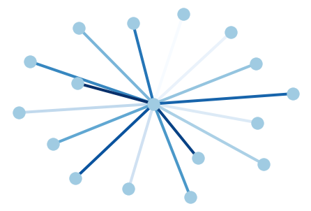

```python
import matplotlib.pyplot as plt
import networkx as nx

G = nx.star_graph(16)
pos = nx.spring_layout(G)
colors = range(16)
options = {
    "node_color": "#A0CBE2",
    "edge_color": colors,
    "width": 4,
    "edge_cmap": plt.cm.Blues,
    "with_labels": False,
}
nx.draw(G, pos, **options)
plt.show()
```

## 1. Numerical Python

The number one on our list is however the bed-rock of them all.  
Numerical python is available as `numpy` on pyPI python package index.  
The continuous development of `numpy` is sponcered by numFOCUS, which is non-profit organization that aims to support mathematical and computational libraries in the python programming language.  
This means that `numpy` is not going away anytime soon, as new and upcomming packages use it as a dependency.  
`numpy` find various applications in completely unrelated fields, like for example, it is a requirement in `spaCy`, CPython implementation for natural language processing.  
`numpy` is traditionally imported as `np` I have another post that deals with 5 `numpy` operations for digital signal processing.  
It has 2 valid and 1 breaking-example each for every operation. To read it click below:

# [Discrete Time Signal Processing using numpy](https://jovian.ml/vedant-madane/numpy-array-operations)